# NYPD - The gun violence and its racial mapping

- Show All Code
- Hide All Code

Graphical overview

Author

Prashant Lamichhane

# Executive summary

In the year of 2022 only, there were approximately 1300 shootings within NYPD. The number, despite being a small reduction from last year with 17% decrease, it is still a huge number. From the data provided by NYPD which is available in Kaggle.com, I have made some analysis and the following graphs were pulled up from it.

[figure not shown]

## Which age group and what race falls under highest shootings in NY?

The code evidently shows that the people with Black racial background have been reported to have more shooters than any other race despite having the population of only 23% of the city which is then followed by white hispanic population.

**Read and Format Data**

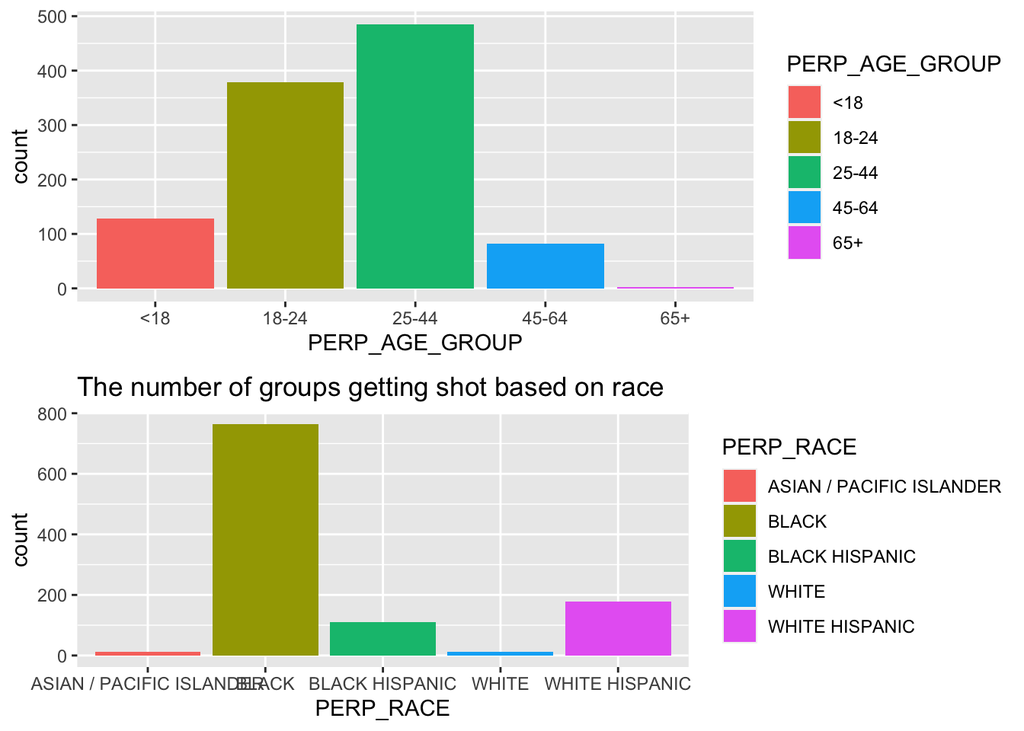

```r
bar_plot_age <- function(){
    data <- filter(my_data, PERP_AGE_GROUP!= "(null)")
    graph <- ggplot(data, aes(PERP_AGE_GROUP, fill = PERP_AGE_GROUP)) +
        geom_bar(stat = "count")+
        labs(titel = "The number of different age groups getting shot")
    return(graph)
}

bar_plot_race <- function(){
    data <- filter(my_data, PERP_RACE!= "(null)")
    graph <- ggplot(data, aes(PERP_RACE, fill = PERP_RACE)) +
        geom_bar(stat = "count") +
        labs(title = "The number of groups getting shot based on race")
    return(graph)
}
plot1 <- bar_plot_age()
plot2 <- bar_plot_race()

print(grid.arrange(plot1, plot2, nrow = 2))
```

## Question 2: Was the shooting rate same form the starting to end or, what upheavel pattern could be seen?

```
[1] "2022-04-12" "2022-12-17" "2022-09-29" "2022-10-16" "2022-08-08"
[1] 2022-09-29 2022-01-09
10 Levels: 2022-04-12 2022-12-17 2022-09-29 2022-08-08 ... 2022-01-09
```

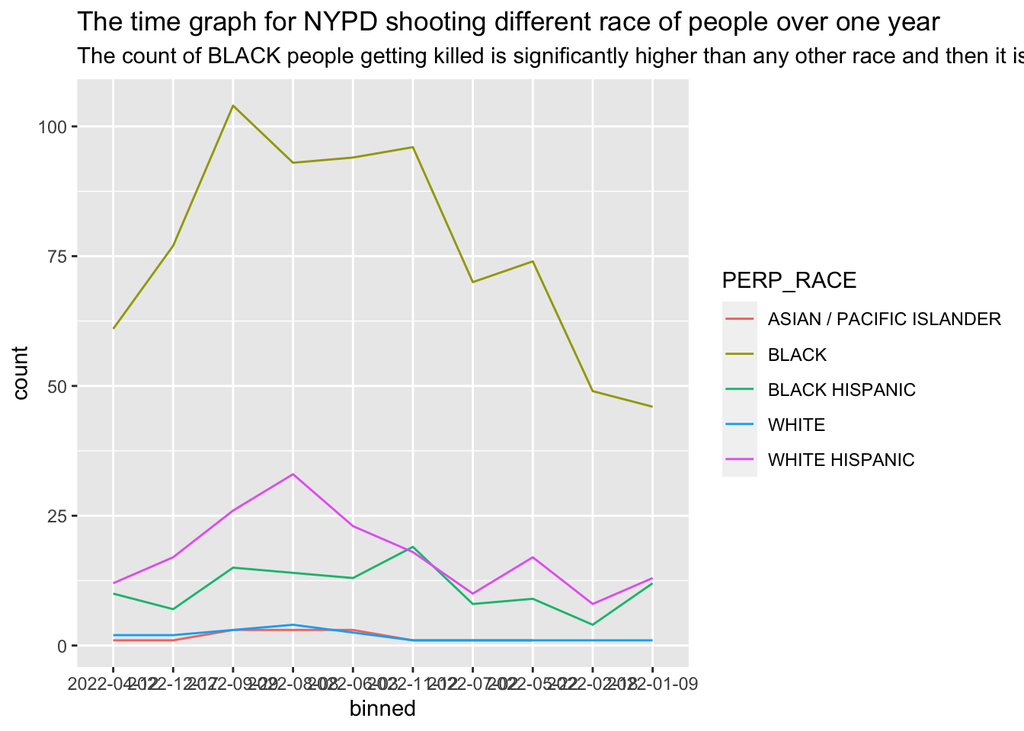

```r
#| label: Q2
#| code-summary: plot
#|fig-align: center
line_graph_race <- function(){
    data <- filter(my_data, PERP_RACE != "(null)")
    data <- filter(data, OCCUR_DATE != "(null)")

    data$OCCUR_DATE <- (as.Date(data$OCCUR_DATE, format = "%m/%d/%Y"))
    print(data$OCCUR_DATE[1:5])
    data$binned <- cut(data$OCCUR_DATE, breaks = 10)
    print(data$binned[1:2])



    graph <- ggplot(data, aes(x = binned, group = PERP_RACE,
     color = PERP_RACE)) +
        geom_freqpoly(stat = "count") +
        labs(title = "The time graph for NYPD shooting different race of people over one year",
        subtitle = "The count of BLACK people getting killed is significantly higher than any other race and then it is followed by White Hispanic.")

    return(graph)
}



print(line_graph_race())
```

## APPENDIX A (Additional R code)

```r
library(ggplot2)
library(tidymodels)
library(tidyverse)
library(gridExtra)
library(lubridate)
library(rpart)



my_data <- read_csv("nypd_shooting.csv")
print(colnames(my_data))

race_bar <- ggplot(my_data, aes(x = PERP_RACE, fill = PERP_RACE)) +
geom_bar(stat = "count") +
labs(title = "Shootings by NYPD to different Races",
subtitle = "Black tops every other race.")

# Question to ask=> What age group and which race in NY
# has higest police shootings?

print(my_data$STATISTICAL_MURDER_FLAG[1:5])

bar_plot_age <- function(){
    data <- filter(my_data, PERP_AGE_GROUP!= "(null)")
    graph <- ggplot(data, aes(PERP_AGE_GROUP, fill = PERP_AGE_GROUP)) +
        geom_bar(stat = "count")+
        labs(titel = "The number of different age groups getting shot")
    return(graph)
}

bar_plot_race <- function(){
    data <- filter(my_data, PERP_RACE!= "(null)")
    graph <- ggplot(data, aes(PERP_RACE, fill = PERP_RACE)) +
        geom_bar(stat = "count") +
        labs(title = "The number of different races getting shot by NYPD")
    return(graph)
}
plot1 <- bar_plot_age()
plot2 <- bar_plot_race()

grid.arrange(plot1, plot2, nrow = 2)


print(my_data$OCCUR_DATE[1:3])
line_graph_race <- function(){
    data <- filter(my_data, PERP_RACE != "(null)")
    data <- filter(data, OCCUR_DATE != "(null)")

    data$OCCUR_DATE <- (as.Date(data$OCCUR_DATE, format = "%m/%d/%Y"))
    print(data$OCCUR_DATE[1:5])
    data$binned <- cut(data$OCCUR_DATE, breaks = 10)
    print(data$binned[1:2])



    graph <- ggplot(data, aes(x = binned, group = PERP_RACE,
     color = PERP_RACE)) +
        geom_freqpoly(stat = "count") +
        labs(title = "The time graph for NYPD shooting different race of people over one year",
        subtitle = "The count of BLACK people getting killed is significantly higher than any other race and then it is followed by White Hispanic.")

    return(graph)
}



print(line_graph_race())

set.seed(123)
```